# Predict profitability of new products

A case study for understanding regression models

Vera Giulia Sala - Ubiqum Code Academy

```r
# load ggplot2 silently
suppressWarnings(library(ggplot2))
# chunk option dev="svg" produces very large vector graphics files
#knitr::opts_chunk$set(dev="svg")
# chunk option dev="png" is the default raster graphics format for HTML output
knitr::opts_chunk$set(dev="png")
```

# 1 Goal of the analysis

The sales team of Blackwell Electronics is considering adding some new products to Blackwell’s product mix. They have shortlisted 17 that fit Blackwell’s business strategy, but now they need help narrowing the list down to five, corresponding to the highest profitable ones. To that end, the goal of the analysis is to build a predictive model, based on the data of the products that are already on the market, that determines the profitabiliy of a product based on a certain number of product attributes. That model will be used to predict the profitability of new products and determine the most rentable one.  
The sales team is also interested in how specific product types perform against each other, i.e. if some product types are more likely to have a higher volume of sales (especially among PC, Laptops, Netbooks and Smartphones).

# 2 Dataset

The “existing products” dataset contains the existing Blackwell product mix, consisting of 80 products. For each product 18 features are recorded:

- Product ID: ‘ProductNum’
- Product type: ‘ProductType’
- Quality attributes: ‘x5StarReviews’, ‘x4StarReviews’, ‘x3StarReviews’, ‘x2StarReviews’ ‘x1StarReviews’, ‘PositiveServiceReview’, ‘NegativeServiceReview’, ‘Wouldconsumerrecommendproduct’, ‘BestSellersRank’
- Physical attributes: ‘ShippingWeight’, ‘ProductDepth’, ‘ProductWidth’, ‘ProductHeight’
- Profit margin: ‘Profitmargin’
- Volume of sales: ‘Volume’

The “new products” dataset contains 24 new products, for which we want to predict the volume of sales.

# 3 Preprocessing and exploratory analysis of data

We perform a first exploration of the existing and new products datasets. We check the data quality (missing values, repeated rows), check the distribution of data and remove ouliers.

## 3.1 First exploration of data

```r
library(reshape2)
library(ggplot2)
library(corrplot)
library(caret)
library(dplyr)
library(knitr)
```

```r
dati_ex <- read.csv("existingproductattributes2017.csv")
dati_new <- read.csv("newproductattributes2017.csv")
```

```r
str(dati_ex)
```

```
## 'data.frame':    80 obs. of  18 variables:
##  $ ProductType          : Factor w/ 12 levels "Accessories",..: 7 7 7 5 5 1 1 1 1 1 ...
##  $ ProductNum           : int  101 102 103 104 105 106 107 108 109 110 ...
##  $ Price                : num  949 2250 399 410 1080 ...
##  $ x5StarReviews        : int  3 2 3 49 58 83 11 33 16 10 ...
##  $ x4StarReviews        : int  3 1 0 19 31 30 3 19 9 1 ...
##  $ x3StarReviews        : int  2 0 0 8 11 10 0 12 2 1 ...
##  $ x2StarReviews        : int  0 0 0 3 7 9 0 5 0 0 ...
##  $ x1StarReviews        : int  0 0 0 9 36 40 1 9 2 0 ...
##  $ PositiveServiceReview: int  2 1 1 7 7 12 3 5 2 2 ...
##  $ NegativeServiceReview: int  0 0 0 8 20 5 0 3 1 0 ...
##  $ Recommendproduct     : num  0.9 0.9 0.9 0.8 0.7 0.3 0.9 0.7 0.8 0.9 ...
##  $ BestSellersRank      : int  1967 4806 12076 109 268 64 NA 2 NA 18 ...
##  $ ShippingWeight       : num  25.8 50 17.4 5.7 7 1.6 7.3 12 1.8 0.75 ...
##  $ ProductDepth         : num  23.9 35 10.5 15 12.9 ...
##  $ ProductWidth         : num  6.62 31.75 8.3 9.9 0.3 ...
##  $ ProductHeight        : num  16.9 19 10.2 1.3 8.9 ...
##  $ ProfitMargin         : num  0.15 0.25 0.08 0.08 0.09 0.05 0.05 0.05 0.05 0.05 ...
##  $ Volume               : int  12 8 12 196 232 332 44 132 64 40 ...
```

```r
a <- as.data.frame(table(dati_ex$ProductType))
b <- as.data.frame(table(dati_new$ProductType))
ggplot(a,aes(x=Var1,y=Freq))+geom_col(fill="gray")+geom_col(data=b,aes(x=Var1,y=Freq),fill="red",alpha=0.5)+ theme(axis.text.x=element_text(angle=60,hjust=1)) + xlab("")+
geom_rect(xmin=8, xmax=8.3, ymin=20, ymax=21, color="red",fill="red",alpha=0.5)+
geom_rect(xmin=8, xmax=8.3, ymin=18, ymax=19, color="gray",fill="gray",alpha=0.5)+
annotate("text", x = 9.5, y = 20.6, label = "New products")+
annotate("text", x = 9.5, y = 18.6, label = "Ex. products")
```

[output not shown]

## 3.2 Missing values: remove BestSellersRank attribute

```r
print(paste("The number of NAs in the existing dataset is ", (sum(is.na(dati_ex)))))
```

```
## [1] "The number of NAs in the existing dataset is  15"
```

```r
print(paste("NAs from the BestSellerRank attribute", (sum(is.na(dati_ex$BestSellersRank)))))
```

```
## [1] "NAs from the BestSellerRank attribute 15"
```

```r
dati_ex <- dati_ex[colnames(dati_ex) != "BestSellersRank"]
dati_new <- dati_new[colnames(dati_new) != "BestSellersRank"]
```

## 3.3 Outliers

We use histograms and scatter plots to identify and remove outliers.

```r
options(repr.plot.width=15, repr.plot.height=3)
p1 <- ggplot(dati_ex,aes(x=Volume))+ geom_histogram()
p2 <- ggplot(dati_ex, aes(x=x4StarReviews, y=Volume))+geom_smooth(method='lm',formula=y~x, col="red")+ geom_point()+           geom_point(data=dati_ex[which(dati_ex$Volume > 6000),],col="blue",size=3)+ geom_point(data=dati_ex[which(dati_ex$Volume < 6000 & dati_ex$x2StarReviews > 40),],col="blue",size=3)+ggtitle("With outliers")
p3 <- ggplot(dati_ex[which(dati_ex$Volume < 6000 & dati_ex$x2StarReviews < 40),], aes(x=x4StarReviews, y=Volume))+geom_smooth(method='lm',formula=y~x, col="red")+ geom_point()+ggtitle("Outliers removed")
multiplot(p1, p2, p3, cols=3)
```

[output not shown]

```r
outliers <- dati_ex[which(dati_ex$Volume > 6000 | dati_ex$x2StarReviews > 40 | dati_ex$NegativeServiceReview > 40 | dati_ex$PositiveServiceReview >200),]
```

```r
dati_ex <- dati_ex[which(dati_ex$Volume < 6000 & dati_ex$x2StarReviews < 40 & dati_ex$NegativeServiceReview < 40 & dati_ex$PositiveServiceReview <200),]
```

```r
dim(dati_ex)
```

```
## [1] 65 17
```

## 3.4 Attributes type: categorical to dummy variables

```r
newDataframe <- dummyVars(" ~ .", data = dati_ex)
dati_ex_d <- data.frame(predict(newDataframe, newdata = dati_ex))
```

# 4 Feature Selection

We use feature selection to determine the set of variables that are more relevant for volume prediction. This process follows three steps:

- elimination of “bad” features
- elimination of collinear features
- feature selection using random forest prediction (feature importance)

## 4.1 Removing “bad” features: x5StarReviews

```r
options(repr.plot.width=10, repr.plot.height=10)
M <- cor(dati_ex_d[!(names(dati_ex_d) %in% c("ProductType"))])
corrplot(M, method="ellipse",order="hclust",tl.cex=0.5)
```

[output not shown]

```r
linmod5 <- lm(Volume ~ x5StarReviews, dati_ex_d)
```

```r
linmod5 <- lm(Volume ~ x5StarReviews, dati_ex_d)
ggplot(dati_ex_d, aes(x=x5StarReviews, y=Volume))+geom_smooth(method='lm',formula=y~x, col="red")+ geom_point()+
annotate("text", x = 150, y = 1700, label = "Volume = 4 * x5StarReviews", col='black')
```

[output not shown]

```r
dati_ex_d <- dati_ex_d[colnames(dati_ex_d) != "x5StarReviews"]
```

## 4.2 Remove collinear features

We remove independent variables that are highly collinear, i.e. having a high correlation coefficient. Specifically, “x3StarReviews” is highly correlated with “x4StarReviews”. We remove “x3StarReviews”, being the variable with the lowest correlation with the dependent variable (Volume).

```r
M <- cor(dati_ex[!(names(dati_ex) %in% c("ProductType","ProductNum","x5StarReviews"))])
corrplot(M, method="number",order="hclust",tl.cex=0.5,number.cex=0.7)
```

[output not shown]

```r
dati_ex_d <- dati_ex_d[colnames(dati_ex_d) != "x3StarReviews"]
```

## 4.3 Feature selection with random forest

We train a random forest model on the full dataset (all features included). From the variables importance given as an output from the model, we determine the most relevant features.

> just two variables are relevant: x4StarReviews, PositiveServiceReview

```r
t <- proc.time()
set.seed(400)
ctrl <- trainControl(method="cv",number=3, repeats = 3)
modrf <- train(Volume ~ ., dati_ex_d[names(dati_ex_d) != "ProductNum"], method = "rf", trControl = ctrl, tuneLength =10)
proc.time()-t
```

```r
print(modrf)
```

```
## Random Forest
##
## 65 samples
## 24 predictors
##
## No pre-processing
## Resampling: Cross-Validated (3 fold)
## Summary of sample sizes: 44, 44, 42
## Resampling results across tuning parameters:
##
##   mtry  RMSE      Rsquared
##    2    292.1074  0.7989546
##    4    247.0589  0.8390187
##    6    229.4458  0.8635939
##    9    211.5507  0.8747538
##   11    200.5826  0.8858079
##   14    189.9035  0.8901191
##   16    184.0814  0.8919258
##   19    171.9224  0.8928755
##   21    165.8687  0.8954004
##   24    161.0419  0.8904398
##
## RMSE was used to select the optimal model using  the smallest value.
## The final value used for the model was mtry = 24.
```

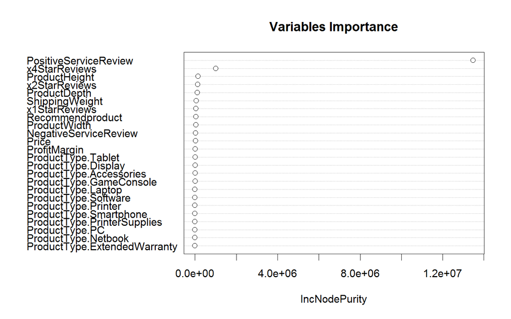

```r
varImpPlot(modrf$finalModel, main="Variables Importance")
```

> From our analysis we see that we can use just two variables (x4StarReviews, PositiveServiceReview) for volume prediction. The product type seems irrelevant for the prediction.